# Spatial Assignment

M.C. Abbott, Manoel Pereira Neto, Jack Halverson

9/22/2021

## Introduction

For our team’s response to the assignment, we decided to break beyond the our Analyze Boston comfort zone to look at another open data rich city, the City of San Francisco. After reviewing the data available from their open portal, we landed on a mix of points and polygons that might help us tell a story of displacement in the city.

“CULTURAL”: This polygon set identifies SF Board of Supervisors-recognized districts that, according to their designation, are distinguished by unique social and historical associations and living traditions. Cultural Districts are focal area for the Planning Department and the Mayor’s Office of Economic and Workforce Development for developing strategies for sustaining the living culture of the area.

“PLANNING”: This polygon set identifies the city’s Planning Districts. Planning Districts are used mainly for analysis and management but are also in some parts of the General Plan.

“INCLUSIONARY”: This point set is a list of the city’s residential projects with inclusionary requirements, part of the city’s Inclusionary Affordable Housing Program. Inclusionary zoning was established by Planning Code Section 415 (http://bit.ly/1ag0AmP), and applies to developments of 10 or more units.

“BUYOUTS”: This point set is the mandated record of any tenant buyouts. Regulation of tenant buyouts went into effect in 2015.

Point allocation: we worked through this project together for the initial data selection and tutorial. We each contributed 2 maps and would allocate as follows: M.C. - 10, Manoel - 10, Jack - 10

## Load packages

```r
library(sf)
library(tidyverse)
library(ggthemes)
library(ggspatial)
library(units)
library(nngeo)
```

## Load and transform data

```r
cultural <- st_read("https://data.sfgov.org/api/geospatial/5xmc-5bjj?method=export&format=KML")
planning <- st_read("https://data.sfgov.org/api/geospatial/ttns-6zj3?method=export&format=KML")
buyouts <- st_read("https://data.sfgov.org/api/geospatial/wmam-7g8d?method=export&format=KML")
inclusionary <- st_read("Residential_Projects_With_Inclusionary_Requirements.kml")

CA_zone_3 <- "+proj=lcc +lat_1=38.43333333333333 +lat_2=37.06666666666667 +lat_0=36.5 +lon_0=-120.5 +x_0=2000000 +y_0=500000 +ellps=GRS80 +units=m +no_defs "

cultural <- cultural %>%
  st_transform(CA_zone_3)

planning <- planning %>%
  st_transform(CA_zone_3)

buyouts <- buyouts %>%
  st_transform(CA_zone_3)

inclusionary <- inclusionary %>%
  st_transform(CA_zone_3)
```

## #1 Rental Buyouts in Buffers Zones of Development Projects with Inclusionary Requirements

[figure not shown]

```r
inclusionary_buffer <- st_buffer(inclusionary, dist = 400) %>%
  st_union()

ggplot(inclusionary_buffer) +
  geom_sf() +
  theme_map()
```

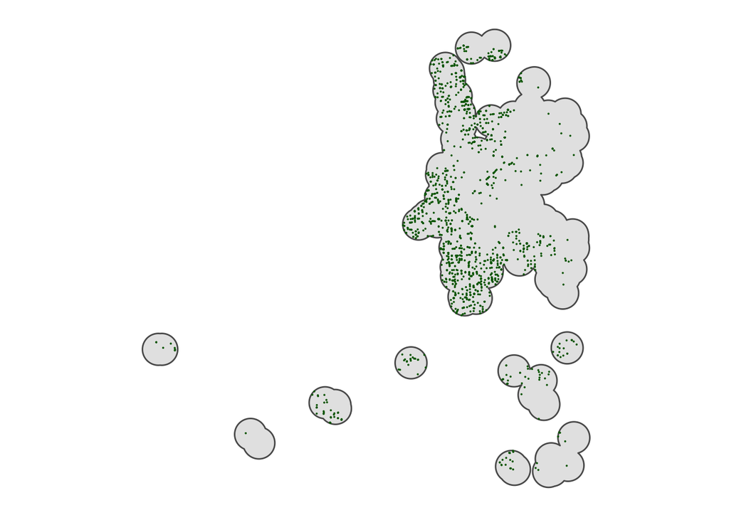

```r
buyouts_inclusionary<- buyouts[inclusionary_buffer,]

ggplot(inclusionary_buffer) +
  geom_sf() +
  geom_sf(data = buyouts_inclusionary,
          color = "darkgreen",
          size = 0.01) +
  theme_map()
```

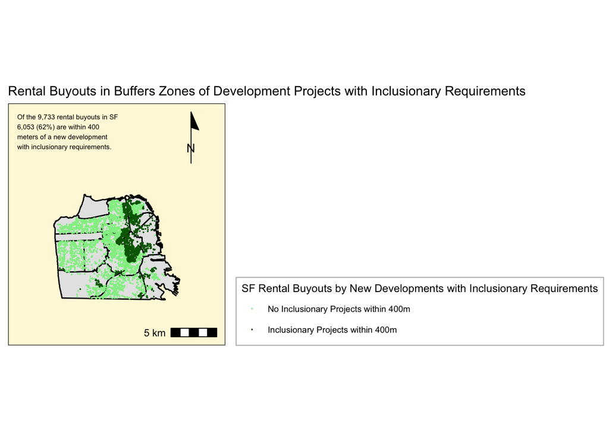

```r
buyouts <- buyouts %>%
  st_join(buyouts_inclusionary) %>%
  mutate(by_inclusionary = !is.na(Description.y))


n_inclusionary_buyouts <- sum(buyouts$by_inclusionary)

n_inclusionary_buyouts


n_buyouts <- length(buyouts$by_inclusionary)

pct_inclusionary_buyouts <- n_inclusionary_buyouts / n_buyouts

pct_inclusionary_buyouts


left_side  <- st_bbox(planning)$xmin
top_side <- st_bbox(planning)$ymax
right_side <- st_bbox(planning)$xmax
bottom_side <- st_bbox(planning)$ymin

ggplot() +
  geom_sf(data = planning, color = "black") +
  geom_sf(data = buyouts, size = 0.01,
          aes(color = by_inclusionary)) +
  scale_color_manual(values = c("lightgreen", "darkgreen"),
          name = "SF Rental Buyouts by New Developments with Inclusionary Requirements",
          labels = c("No Inclusionary Projects within 400m",
                     "Inclusionary Projects within 400m")) +
  coord_sf(xlim = c(left_side-5000, right_side+5000),
           ylim = c(bottom_side-5000, top_side+10000), expand = FALSE) +
  annotation_scale(location = "br") +
  annotation_north_arrow(location = "tr",
                         style = north_arrow_minimal()) +
  annotate(geom = "text",
            x = left_side - 4000,
            y = top_side + 5000,
            label = paste ("Of the ",
                         prettyNum(n_buyouts, big.mark = ","),
                         " rental buyouts in SF\n",
                         prettyNum(n_inclusionary_buyouts, big.mark = ","),
                         " (",
                         prettyNum(100*pct_inclusionary_buyouts, digits = 0),
                         "%) are within 400\nmeters of a new development\nwith inclusionary requirements.",
                         sep = ""),

            hjust = 0, vjust = 0, size = 2) +
  theme_map() +
  theme(panel.background = element_rect(fill = "cornsilk1"),
        legend.background = element_rect(fill = alpha("white", 0.5),
                                         color = "gray")) +
  theme(legend.position = "right") +
  ggtitle( "Rental Buyouts in Buffers Zones of Development Projects with Inclusionary Requirements")
```

For this first map, we looked at the number and proportion of buyouts within one-quarter mile of a mandated inclusionary housing development projects. Given over half of buyouts take place within a quarter mile of an inclusionary project, it would seem that there is a prominent impact that these developments are having on the residential makeup of a neighborhood. What the map makes clear is a tension between the buyout (displacement) of existing residence, and efforts by the city to retain housing for essential, below-market-rate wage earners. A hypothesis we have is that those that are being bought out are not staying in the area, and instead mandated affordable housing is being filled by different populations, which ultimately undermines inclusionary mandates as an anti-displacement effort, but additional data would need to be found and/or produced to add the temporal dimension of where residents move to after a buyout.

## #3 Average distance of Projects with Inclusionary Requirements from Rental Buyouts

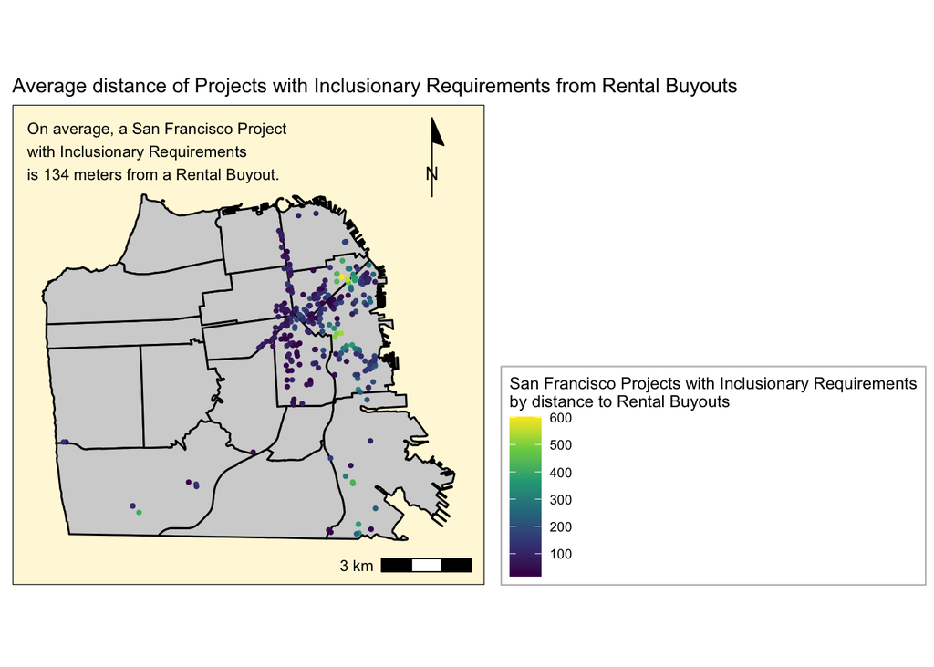

```r
inclusionary <- inclusionary %>%
  mutate(buyouts_dist = st_nn(inclusionary, buyouts,
                           returnDist = TRUE)$dist) %>%
  mutate(buyouts_dist = as.numeric(buyouts_dist))


avg_buyouts_dist <- mean(inclusionary$buyouts_dist)

avg_buyouts_dist


right_side <- st_bbox(planning)$xmax
left_side  <- st_bbox(planning)$xmin
top_side <- st_bbox(planning)$ymax
bottom_side <- st_bbox(planning)$ymin

ggplot() +
  geom_sf(data = planning,fill = "light gray", color = "black") +
  geom_sf(data = inclusionary, size = 0.75,
          aes(color = buyouts_dist)) +
  coord_sf(xlim = c(left_side-1000, right_side+1000),
           ylim = c(bottom_side-1500, top_side+3000), expand = FALSE) +
  scale_color_viridis_c(name =
                          "San Francisco Projects with Inclusionary Requirements\nby distance to Rental Buyouts") +
  annotation_scale(location = "br") +
  annotation_north_arrow(location = "tr",
                         style = north_arrow_minimal()) +
  annotate(geom = "text", x = left_side - 500,
           y = top_side + 500,
           label = paste("On average, a San Francisco Project\nwith Inclusionary Requirements\nis ",
                         prettyNum(avg_buyouts_dist, digits = 3),
                         " meters from a Rental Buyout.",
                         sep = ""),
           hjust = 0, vjust = 0, size = 3) +
  theme_map() +
  theme(panel.background = element_rect(fill = "cornsilk1"),
        legend.background = element_rect(fill = alpha("white", 0.5),
                                         color = "gray")) +
  theme(legend.position = "right") +
  ggtitle( "Average distance of Projects with Inclusionary Requirements from Rental Buyouts")
```

Building on the previous analysis, for this map, we looked at the average distance between a mandated inclusionary housing development project and the nearest buyout. This maps provides a finer tune on the map above, with an explicit calculation of the average distance, a mere 134 meters between an inclusionary mandated project and a buyout.

## #5: Number and Proportion of Rental Buyouts within Cultural Districts

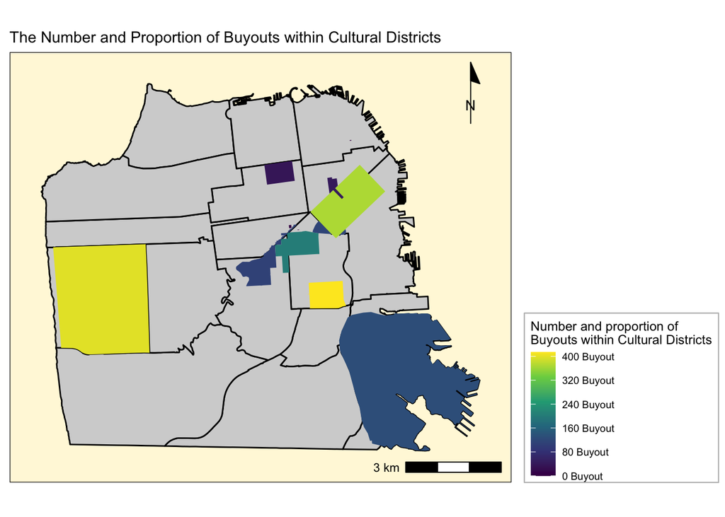

```r
cultural <- cultural %>%
  mutate(num_buyouts = lengths(st_covers(cultural, buyouts)))
ggplot() +
  geom_sf(data = planning, fill = "light gray", color = "black") +
  geom_sf(data = cultural, color = NA,
          aes(fill = num_buyouts)) +
  scale_fill_viridis_c(name = "Number and proportion of \nBuyouts within Cultural Districts",
                       breaks = breaks <- seq(0, 500, by = 80),
                       labels = paste(prettyNum(breaks, big.mark = ","),
                                      "Buyout")) +
  coord_sf(xlim = c(left_side-1000, right_side+1000),
           ylim = c(bottom_side-1000, top_side+1000), expand = FALSE) +
  annotation_scale(location = "br") +
  annotation_north_arrow(location = "tr",
                         style = north_arrow_minimal()) +
theme_map() +
theme(panel.background = element_rect(fill = "cornsilk1"),
        legend.background = element_rect(fill = alpha("white", 0.5),
                                         color = "gray")) +
  theme(legend.position = "right")+

ggtitle( "The Number and Proportion of Buyouts within Cultural Districts")
```

## #7 The Number of Inclusionary Projects within Cultural Districts

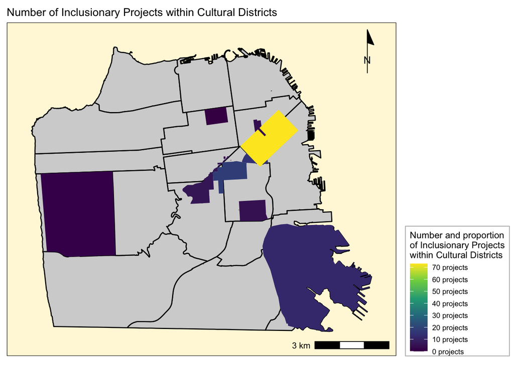

```r
cultural <- cultural %>%
  mutate(num_inclusionary = lengths(st_covers(cultural, inclusionary)))
ggplot() +
  geom_sf(data = planning, fill = "light gray", color = "black") +
  geom_sf(data = cultural, color = NA,
          aes(fill = num_inclusionary)) +
  scale_fill_viridis_c(name = "Number and proportion\nof Inclusionary Projects\nwithin Cultural Districts",
                       breaks = breaks <- seq(0, 100, by = 10),
                       labels = paste(prettyNum(breaks, big.mark = ","),
                                      "projects")) +
  coord_sf(xlim = c(left_side-1000, right_side+1000),
           ylim = c(bottom_side-1000, top_side+1000), expand = FALSE) +
  annotation_scale(location = "br") +
  annotation_north_arrow(location = "tr",
                         style = north_arrow_minimal()) +
theme_map() +
theme(panel.background = element_rect(fill = "cornsilk1"),
        legend.background = element_rect(fill = alpha("white", 0.5),
                                         color = "gray")) +
  theme(legend.position = "right") +
  ggtitle( "Number of Inclusionary Projects within Cultural Districts")
```

In conversation with our previous map, we see once again that the neighborhood of SOMA is the location of the highest number of inclusionary mandated housing developments. What we know from our personal experience is that this area has been consumed in the last 5 years by the spillover of the tech industry, a mixture of office space, commercial development and housing all catered to the tech industry. While the data here doesn’t go granular into WHO is subject to the buyouts, it’s likely given the high percentage of buyouts that the efforts have not been successful in retaining its cultural vibrancy, which puts into question the effectiveness of the city’s inclusionary mandate mechanism.

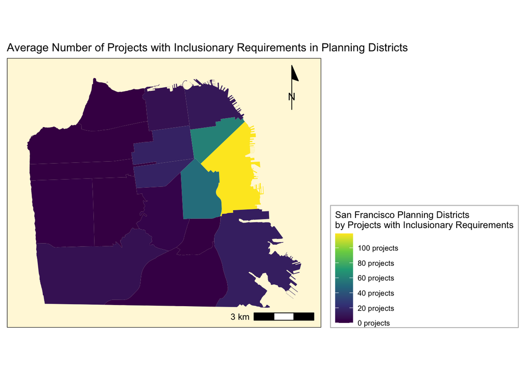

```r
planning <- planning %>%
  mutate(num_inclusionary = lengths(st_covers(planning, inclusionary)))


right_side <- st_bbox(planning)$xmax
left_side  <- st_bbox(planning)$xmin
top_side <- st_bbox(planning)$ymax
bottom_side <- st_bbox(planning)$ymin

ggplot(planning) +
  geom_sf(color = NA,
          aes(fill = num_inclusionary)) +
  coord_sf(xlim = c(left_side-1000, right_side+1000),
           ylim = c(bottom_side-1000, top_side+1000), expand = FALSE) +
  scale_fill_viridis_c(name = "San Francisco Planning Districts\nby Projects with Inclusionary Requirements",
                       breaks = breaks <- seq(0, 120, by = 20),
                       labels = paste(prettyNum(breaks, big.mark = ","),
                                      "projects")) +
  annotation_scale(location = "br") +
  annotation_north_arrow(location = "tr",
                         style = north_arrow_minimal()) +
theme_map() +
  theme(panel.background = element_rect(fill = "cornsilk1"),
        legend.background = element_rect(fill = alpha("white", 0.5),
                                         color = "gray")) +
  theme(legend.position = "right") +
  ggtitle( "Average Number of Projects with Inclusionary Requirements in Planning Districts")
```

In this map, we are analyzing the number of mandated inclusionary housing development projects in each planning district. This map might tell us something about the political landscape of the city, an understanding of which districts are focused on density in their housing developments, given the inclusionary requirement for buildings over 10 units. Here we again see SOMA, despite its Cultural District designation, as the epicenter of dense development for the city. Of course this map doesn’t provide the nuance of where exactly in this large tract the density is focused, and it would be interested to see if within this area there are particular “hot zones” for dense, vertical growth, compared to areas where projects are of a smaller size.

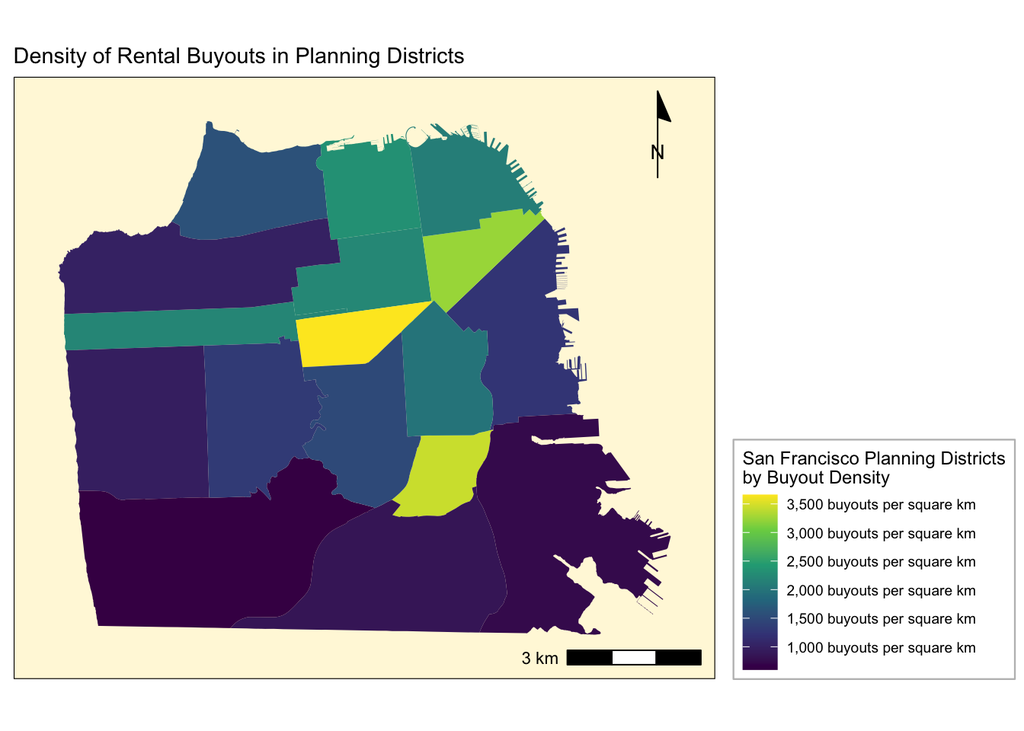

```r
planning <- planning %>%
  mutate(area = set_units(st_area(planning), km^2)) %>%
  mutate(buyouts_dens = as.numeric(n_buyouts / area))

right_side <- st_bbox(planning)$xmax
  left_side  <- st_bbox(planning)$xmin
  top_side <- st_bbox(planning)$ymax
  bottom_side <- st_bbox(planning)$ymin

  ggplot() +
  geom_sf(data = planning, color = NA, aes(fill = buyouts_dens)) +
  scale_fill_viridis_c(name =
                           "San Francisco Planning Districts\nby Buyout Density",
                       breaks = breaks <- seq(0, 4000, by = 500),
                       labels = paste(prettyNum(breaks, big.mark = ","),
                                      "buyouts per square km")) +
  coord_sf(xlim = c(left_side-1000, right_side+1000),
           ylim = c(bottom_side-1000, top_side+1000), expand = FALSE) +


  annotation_scale(location = "br") +
  annotation_north_arrow(location = "tr",
                         style = north_arrow_minimal()) +


  theme_map() +
  theme(panel.background = element_rect(fill = "cornsilk1"),
        legend.background = element_rect(fill = alpha("white", 0.5),
                                         color = "gray")) +
  theme(legend.position = "right") +
  ggtitle( "Density of Rental Buyouts in Planning Districts")
```